# Example homework document

### Exercise 2, p.38 of MS

Find a closed-form solution for the affine recurrence relation, $x(n) = Rx(n-1) + a$ My approach is to linearize the equation by a change of variables, use the closed form solution for linear models, and then back-transform to the original state variable. To guide my choice of variable I will first find a fixed point, $x{\star}$, $x{\star} = Rx{\star} + a$ $x{\star} = \frac{a}{1-R}$ I now define a new variable, $y(n)$, which is the deviation of $x(n)$ from $x{\star}$, $y(n) = x(n) - x(\star) = x(n) - \frac{a}{1-R}$ Transforming the original model we obtain, $y(n) + x{\star} = R(y(n-1) + x{\star}) + a$ $y(n) = Ry(n-1) - x{\star}(1-R) + a$ $y(n) = Ry(n-1) - a + a$ $y(n) = Ry(n-1)$ This is a linear model in $y(n)$, with solution, $y(n) = n(0)R^n$ Back-transforming yields, $x(n) - x{\star} = (x(0) - x{\star})R^n$ $x(n) = (x(0) - x{\star})R^n + x{\star}$ $x(n) = x(0)R^n + x{\star}(1 - R^n)$ $x(n) = x(0)R^n + \frac{a(1 - R^n)}{1 - R}$

This solution allows us to straightforwardly identify the difference between a linear model and an affine model, $\underbrace{x(n) = x(0)R^n}_{\text{linear part}} + \underbrace{\frac{a(1 - R^n)}{1 - R}}_{\text{affine part}}$

### Additional requirement

Additionally, we are required to graph the affine model for $R=0.5, a=1, x(0)=1$ for twenty time steps, and highlighting $x{\star}$ and $x(0)$,

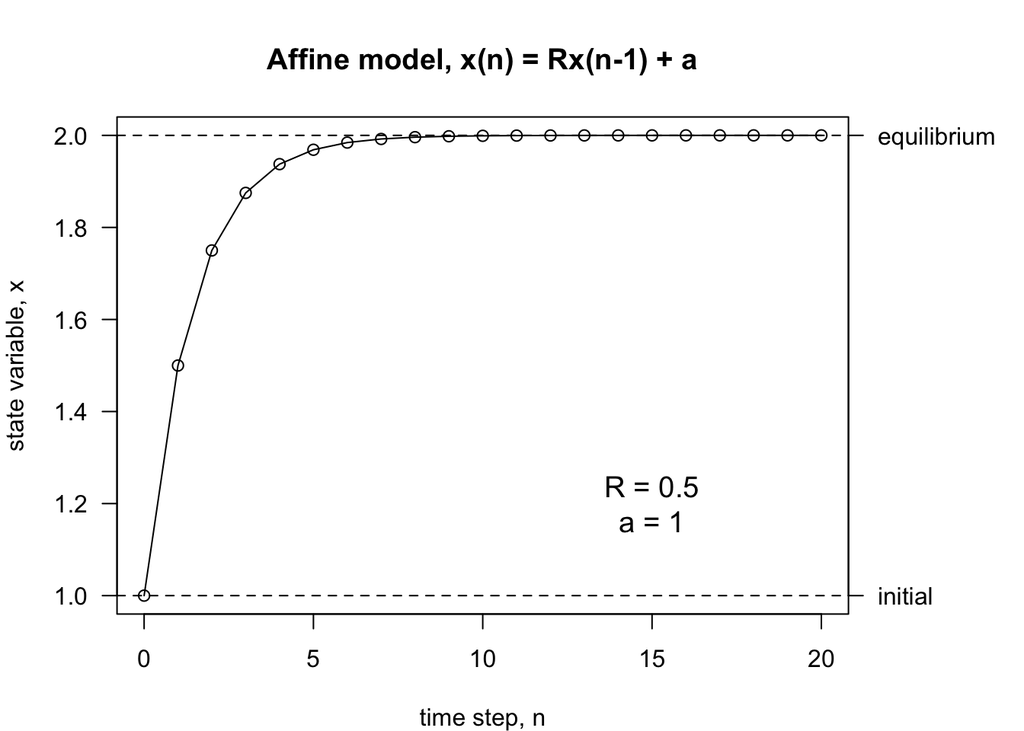

```r
nMax <- 20
R <- 0.5
a <- 1
x0 <- 1
n <- 0:nMax
x <- x0*(R^n) + (a*(1-R^n))/(1-R)
par(mar = c(4, 4, 4, 6))
plot(0:nMax, x, type = "o", las = 1,
     xlab = "time step, n", ylab = "state variable, x",
     main = "Affine model, x(n) = Rx(n-1) + a")
abline(h = c(x0, a/(1-R)), lty = 2)
axis(side = 4, at = c(x0, a/(1-R)),
     labels = c("initial","equilibrium"),
     las = 1)
text(x = 15, y = 1.2, "R = 0.5\na = 1",
     cex = 1.2)
```